# Palmer Penguins

Ella Kaye

29/07/2020

```r
library(tidyverse)
library(palmerpenguins)
library(ragg)
library(ggtext)
```

## Note on the fonts

The plot uses Museo Slab for the title and Futura Light elsewhere. Both are ‘user’ fonts saved on my computer. Museo Slab is available for free [here](https://www.myfonts.com/fonts/exljbris/museo-slab/500/). I’m not sure where I originally bought Futura Light from. I only have the ‘Light’ family from Futura in Font Book, so when I specify `family = "Futura"` in the call to `theme`, then it automatically picks up that. If I had other versions of Futura as well, I suspect I would have had to specify that I wanted the ‘Light’ version somehow. Futura is a professional font that needs paying for. There are [lots](https://www.myfonts.com/search/Futura) of different versions. I’m not sure where I got it from originally, but Font Book tells me it’s by bitstream, so I think it’s this one [here](https://www.myfonts.com/fonts/bitstream/futura/pro-light-193053/).

Figuring out how to get .otf fonts to work with `ggplot` was tricky. The `ragg` package is the answer. See [here](https://www.tidyverse.org/blog/2019/07/ragg-0-1-0/) and [here](https://www.tidyverse.org/blog/2020/05/updates-to-ragg-and-systemfonts/). I had trouble getting plot size, font size and resolution to work nicely together when using the `agg_png()` function (as in the example [here](https://www.tidyverse.org/blog/2019/07/ragg-0-1-0/#example)), but using `agg_png` as the `device` argument in `ggsave` sorted those issues.

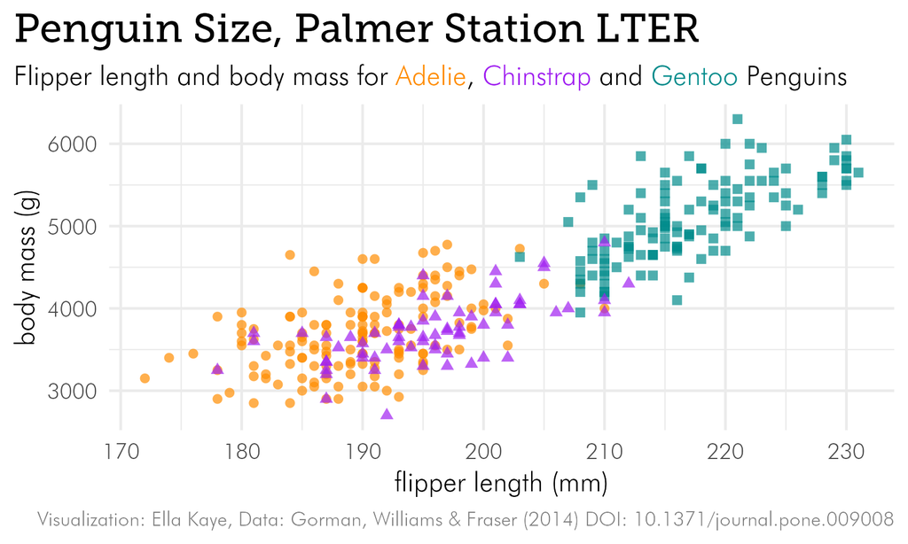

```r
file <- knitr::fig_path('palmerpenguin-font-plot.png', number = NULL)

p <- ggplot(penguins, aes(flipper_length_mm, body_mass_g, group = species)) +
  geom_point(aes(colour = species, shape = species), alpha = 0.7) +
  scale_color_manual(values = c("darkorange","purple","cyan4")) +
  labs(title = "Penguin Size, Palmer Station LTER",
       subtitle = "Flipper length and body mass for <span style = 'color:darkorange;'>Adelie</span>, <span style = 'color:purple;'>Chinstrap</span> and <span style = 'color:cyan4;'>Gentoo</span> Penguins",
       caption = "Visualization: Ella Kaye, Data: Gorman, Williams & Fraser (2014) DOI: 10.1371/journal.pone.009008",
       x = "flipper length (mm)",
       y = "body mass (g)") +
  theme_minimal() +
  theme(legend.position = 'none',
        text = element_text(family = "Futura"),
        # (I only have 'Light' )
        plot.title = element_text(family = "Museo Slab", size = 16),
        plot.subtitle = element_markdown(), # element_markdown from `ggtext` to parse the css in the subtitle
        plot.title.position = "plot",
        plot.caption = element_text(size = 8, colour = "grey50"),
        plot.caption.position = "plot")

# use agg_png from `ragg` as device for high quality image and access to .otf fonts
# res = 320 for retina quality
ggsave(file, p, device = agg_png, res = 320, unit = "in", width = 5, height = 3)

knitr::include_graphics(file)
```

```r
file <- knitr::fig_path('palmerpenguin-font-plot.pdf', number = NULL)

# This works
ggsave(file, p, device = cairo_pdf, unit = "in", width = 5, height = 3)

# Can't include a .pdf image in a html document
# Works fine if I knit to `pdf_document`
# knitr::include_graphics(file)
```